# marginalization of routine inflammatory parameters data on age and sex

The Goal of this notebook is to marginalize the effect of sex and age for each of the routine inflammatory parameters in order to account for differences in median age and sex between the patient groups when testing for significant differences.

The resulting data is the basis for figure 2 A and B

```python
import numpy as np
import matplotlib.pyplot as plt
import scipy.stats as stats
import seaborn as sns
import pandas as pd
```

# TOC

1. reading the data

2. representing columns of interest

3. marginalization

- 3.1 removing outliers
- 3.2 linear models
- 3.3 Summary of marginalization results

4. marginalization of CSF/plasma glucose ratio

- 4.1 reading de data and computing the ratio
- 4.2 testing marginalization
- 4.3. output of marginalized data

# 1. reading the data

```python
df = pd.read_table("data/clinical_info.csv",
              index_col=0 , header=1, skiprows=[2], na_values=['na'])

df.columns
```

```
Index(['Usb Pat Number', 'Age', 'Sex', 'ICU / Stroke U',
       'CSF Cell count (leukocytes)', 'CSF lactate', 'CSF protein',
       'CSF blood albumin ratio', 'CSF glucose', 'Unnamed: 10', 'Unnamed: 11',
       'Unnamed: 12', 'Unnamed: 13', 'Unnamed: 14', 'Unnamed: 15',
       'Discharged home', 'Died in-hospital', 'died in hospital',
       'Unnamed: 19', 'Date of admission/diagnosis', 'Date of LP',
       'Date of blood withdrawal', 'Date of MRI/CT', 'imaging modality',
       'Unnamed: 25', 'Unnamed: 26'],
      dtype='object')
```

```python
df.rename(columns={'Unnamed: 19':"Stage"} , inplace=True)
df.head()
```

| Study ID | Usb Pat Number | Age | Sex | ICU / Stroke U | CSF Cell count (leukocytes) | CSF lactate | CSF protein | CSF blood albumin ratio | CSF glucose | Unnamed: 10 | ... | Died in-hospital | died in hospital | Stage | Date of admission/diagnosis | Date of LP | Date of blood withdrawal | Date of MRI/CT | imaging modality | Unnamed: 25 | Unnamed: 26 |
| --- | --- | --- | --- | --- | --- | --- | --- | --- | --- | --- | --- | --- | --- | --- | --- | --- | --- | --- | --- | --- | --- |
| NC001 | 3595467.0 | 52 | male | 0 | NaN | NaN | NaN | NaN | NaN | NaN | ... | NaN | 0.0 | II | NaN | NaN | NaN | NaN | NaN | NaN | NaN |
| NC002 | 3142334.0 | 34 | female | 0 | 4.0 | 1.52 | 429.0 | NaN | 3.5 | NaN | ... | NaN | 0.0 | II | 8/16/2020 | 8/18/2020 | 8/18/2020 | 8/17/2020 | MRI | t1_mprage | NaN |
| NC003 | 3783056.0 | 48 | male | 1 | 14.0 | 2.94 | 881.0 | 19.9 | 5.7 | NaN | ... | NaN | 0.0 | III | 10/10/2020 | 10/13/2020 | 10/13/2020 | 10/23/2020 | MRI | t1_mprage | NaN |
| NC004 | 3757171.0 | 59 | female | 0 | 1.0 | 1.80 | 174.0 | NaN | 4.4 | NaN | ... | NaN | 0.0 | II | 10/19/2020 | 10/23/2020 | 10/23/2020 | 10/23/2020 | MRI | t1_mprage | NaN |
| NC005 | 2145457.0 | 68 | male | 0 | 7.0 | 2.53 | 378.0 | 8.8 | 7.2 | NaN | ... | NaN | 0.0 | II | 10/29/2020 | 11/2/2020 | 11/2/2020 | 10/29/2020 | MRI | t1_mprage | NaN |

5 rows × 26 columns

```python
df.dtypes
```

```
Usb Pat Number                 float64
Age                              int64
Sex                             object
ICU / Stroke U                   int64
CSF Cell count (leukocytes)    float64
CSF lactate                    float64
CSF protein                    float64
CSF blood albumin ratio        float64
CSF glucose                    float64
Unnamed: 10                    float64
Unnamed: 11                    float64
Unnamed: 12                    float64
Unnamed: 13                    float64
Unnamed: 14                    float64
Unnamed: 15                    float64
Discharged home                float64
Died in-hospital               float64
died in hospital               float64
Stage                           object
Date of admission/diagnosis     object
Date of LP                      object
Date of blood withdrawal        object
Date of MRI/CT                  object
imaging modality                object
Unnamed: 25                     object
Unnamed: 26                     object
dtype: object
```

```python
dfC = pd.read_table("data/Neurocovid_Hutter_Datasheet_08_06_2021_JO.csv", sep=',',
              index_col=1 , header=0, skiprows=[0,1,2,4], na_values=['na',''])

dfC.Consens = dfC.Consens.str.strip('"')

dfC.head()
```

| Code | Unnamed: 0 | DOB | Age | gender | Consens | Date of LP | CSF erythrocytes | CSF colour | CSF lactate | Plasma lactate | ... | CSF total protein | CSF albumin | Albumin ratio CSF/serum | reference | Reiber IgG | Reiber IgA | Reiber IgM | IgG Index | Isoelectric focusing CSf specific bands | n bands |
| --- | --- | --- | --- | --- | --- | --- | --- | --- | --- | --- | --- | --- | --- | --- | --- | --- | --- | --- | --- | --- | --- |
| 4927 | 1 | 5/19/1970 | 38.7 | f | healthy control | 1/14/2009 | 0 | clear | 1.5 | 1.4 | ... | 291 | 153 | 3.3 | 6.6 | 0.0 | 0.0 | 0.0 | 0.50 | negative | 0 |
| 5050 | 1 | 1/12/1956 | 53.5 | m | healthy control | 7/7/2009 | 0 | clear | 1.7 | 1.2 | ... | 400 | 233 | 5.4 | 7.6 | 0.0 | 0.0 | 0.0 | 0.51 | negative | 0 |
| 5052 | 1 | 12/18/1986 | 22.6 | m | healthy control | 7/9/2009 | 0 | clear | 1.8 | 1.4 | ... | 416 | 271 | 5.8 | 5.5 | 0.0 | 0.0 | 0.0 | 0.48 | negative | 0 |
| 5062 | 1 | 2/11/1986 | 23.5 | m | healthy control | 7/28/2009 | 0 | clear | 1.5 | 1.3 | ... | 272 | 173 | 3.7 | 5.6 | 0.0 | 0.0 | 0.0 | 0.57 | negative | 0 |
| 5092 | 1 | 2/7/1962 | 47.6 | f | healthy control | 9/21/2009 | 0 | clear | 1.4 | 1.5 | ... | 427 | 266 | 7.2 | 7.2 | 0.0 | 0.0 | 0.0 | 0.54 | negative | 0 |

5 rows × 26 columns

```python
controlColumns = ["Age","gender","Consens",
                  "CSF leukocytes",
                  "CSF total protein",
                  "Albumin ratio CSF/serum ",
                  "CSF lactate",
                  "CSF glucose"]
covidColumns = ["Age","Sex","Stage",
                "CSF Cell count (leukocytes)",
                "CSF protein",
                "CSF blood albumin ratio",
                "CSF lactate",
                "CSF glucose"]
```

```python
dfC.loc[5977,controlColumns]
```

```
Age                                    59.3
gender                                    f
Consens                     healthy control
CSF leukocytes                    1000000.0
CSF total protein                       278
Albumin ratio CSF/serum                 6.4
CSF lactate                             1.8
CSF glucose                             3.7
Name: 5977, dtype: object
```

```python
dfC.columns
```

```
Index(['Unnamed: 0', 'DOB', 'Age', 'gender', 'Consens', 'Date of LP',
       'CSF erythrocytes', 'CSF colour', 'CSF lactate', 'Plasma lactate',
       'CSF glucose', 'Plasma glucose', 'glucose ratio CSF/plasma ',
       'CSF leukocytes', 'mononuclear', 'polynuclear', 'CSF total protein',
       'CSF albumin', 'Albumin ratio CSF/serum ', 'reference', 'Reiber IgG',
       'Reiber IgA', 'Reiber IgM', 'IgG Index',
       'Isoelectric focusing CSf specific bands', 'n bands'],
      dtype='object')
```

```python
sdf = df.loc[ : , covidColumns ].rename( columns={"CSF Cell count (leukocytes)":"CSF_leukocytes",
                  "CSF protein":"CSF_protein",
                  "CSF blood albumin ratio":"CSF_blood_albumin_ratio",
                  "CSF lactate":"CSF_lactate",
                  "CSF glucose": "CSF_glucose"} )

sCdf = dfC.loc[ : , controlColumns ].rename( columns={"gender":"Sex",
                                                  "Consens":"Stage",
                                                  "CSF total protein":"CSF_protein",
                                                  "Albumin ratio CSF/serum ":"CSF_blood_albumin_ratio",
                                                  "CSF lactate":"CSF_lactate",
                                                  "CSF glucose": "CSF_glucose",
                                                  "CSF leukocytes":"CSF_leukocytes"} )
```

```python
df_merged = pd.concat( [ sCdf , sdf] )
df_merged.head()
```

|  | Age | Sex | Stage | CSF_leukocytes | CSF_protein | CSF_blood_albumin_ratio | CSF_lactate | CSF_glucose |
| --- | --- | --- | --- | --- | --- | --- | --- | --- |
| 4927 | 38.7 | f | healthy control | 4.3 | 291.0 | 3.3 | 1.5 | 3.0 |
| 5050 | 53.5 | m | healthy control | 0.7 | 400.0 | 5.4 | 1.7 | 3.5 |
| 5052 | 22.6 | m | healthy control | 0.3 | 416.0 | 5.8 | 1.8 | 7.1 |
| 5062 | 23.5 | m | healthy control | 1.0 | 272.0 | 3.7 | 1.5 | 3.4 |
| 5092 | 47.6 | f | healthy control | 2.3 | 427.0 | 7.2 | 1.4 | 2.8 |

```python
df_merged.Sex = df_merged.Sex.str.replace("male","m")
df_merged.Sex = df_merged.Sex.str.replace("female","f")
df_merged.Sex = df_merged.Sex.str.replace("F","f")
df_merged.Sex = df_merged.Sex.str.replace("M","m")
df_merged.Sex = df_merged.Sex.str.replace("fem","f")
df_merged.Sex.value_counts()
```

```
m    49
f    41
Name: Sex, dtype: int64
```

```python
df_merged.Stage = df_merged.Stage.str.replace( "inflammatory controll","inflammatory control" )
df_merged.Stage.value_counts()
```

```
healthy control         25
inflammatory control    25
I                       18
III                     15
II                       7
Name: Stage, dtype: int64
```

toc

# 2. representing columns of interest

Columns of interest :

- "CSF Cell count (leukocytes)"
- "CSF lactate"
- "CSF protein"
- "CSF blood albumin ratio"
- "CSF glucose"

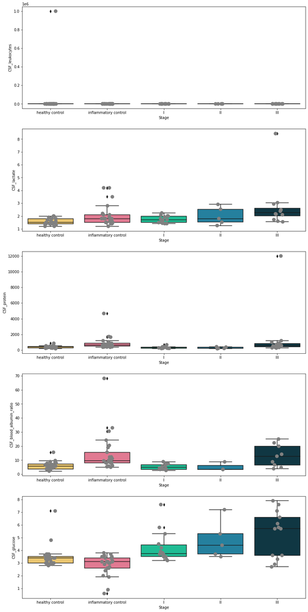

```python
# red/yellow / turquoise / blues
palette5 = {'III' :'#073B4C',
    'II' : '#118AB2',
       'I' : '#06D6A0',
    'healthy control' : '#FFCE5C',
    'inflammatory control' : '#F26989' }
Gorder = [ 'healthy control' ,'inflammatory control',  "I" , 'II' , "III" ]


fig,axes = plt.subplots(5,1,figsize=(14,6*5))
for i,col in enumerate([ "CSF_leukocytes","CSF_lactate","CSF_protein","CSF_blood_albumin_ratio","CSF_glucose"]):


    sns.boxplot( data = df_merged , x = 'Stage' , y =col , palette=palette5,order=Gorder , ax = axes[i])
    sns.stripplot( data = df_merged , x = 'Stage' , y = col , size=10,
                  color="grey",order=Gorder, ax=axes[i])
```

To investigate differences between these group, a approach similar to the one deployed on the molecular data seems appropriate (ie. marginalization on age and sex followed by statistical testing of difference in location between groups).

Note :

toc

# 3. marginalization

A first run of linear models shows that the outliers do have an important effect on the regressions.

The first step should therefore be to exclude them while computing the effect of age and sex:

## 3.1 removing outliers

```python
df_merged_no_outliers = df_merged.copy()
```

```python
df_merged_no_outliers.loc['NC040',"CSF_leukocytes"] = np.nan
df_merged_no_outliers.loc['NC040',"CSF_protein"] = np.nan
df_merged_no_outliers.loc[5977,"CSF_leukocytes"] = np.nan

df_merged_no_outliers.CSF_leukocytes.describe()
```

```
count     79.000000
mean      26.296203
std       89.509391
min        0.000000
25%        1.000000
50%        2.300000
75%       10.800000
max      719.000000
Name: CSF_leukocytes, dtype: float64
```

```python
## potential outlier for lactate as well
df_merged_no_outliers.loc['NC040',"CSF_lactate"] = np.nan
```

toc

## 3.2 linear models

```python
## some measures indicate an amount of heteroskedascticity. Let's try log-transformation

df_merged_no_outliers["CSF_lactate_log"] = np.log10(df_merged_no_outliers.CSF_lactate)
df_merged_no_outliers["CSF_leukocytes_log"] = np.log10(0.1+df_merged_no_outliers.CSF_leukocytes)
df_merged_no_outliers["CSF_protein_log"] = np.log10(df_merged_no_outliers.CSF_protein)
df_merged_no_outliers["CSF_blood_albumin_ratio_log"] = np.log10(df_merged_no_outliers.CSF_blood_albumin_ratio)

df_merged["CSF_lactate_log"] = np.log10(df_merged.CSF_lactate)
df_merged["CSF_leukocytes_log"] = np.log10(0.1+df_merged.CSF_leukocytes)
df_merged["CSF_protein_log"] = np.log10(df_merged.CSF_protein)
df_merged["CSF_blood_albumin_ratio_log"] = np.log10(df_merged.CSF_blood_albumin_ratio)
```

```python
import statsmodels.api as sm
import statsmodels.formula.api as smf
```

```python
palette5 = {'III' :'#073B4C',
    'II' : '#118AB2',
       'I' : '#06D6A0',
    'healthy control' : '#FFCE5C',
    'inflammatory control' : '#F26989' }

order5 = ['healthy control','inflammatory control','I','II','III']


## thankfully, the global median value is plausible for all categories (ie. close the the group medians and observed points)
medianAge = df_merged.Age.median()

ageDiff = df_merged.Age - medianAge
sexDiff = df_merged.Sex == 'm'
```

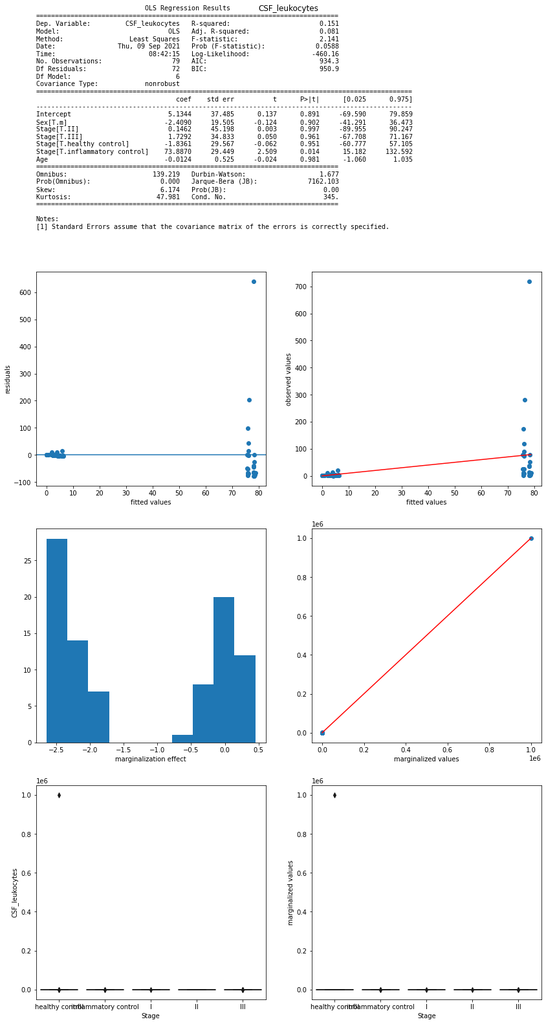

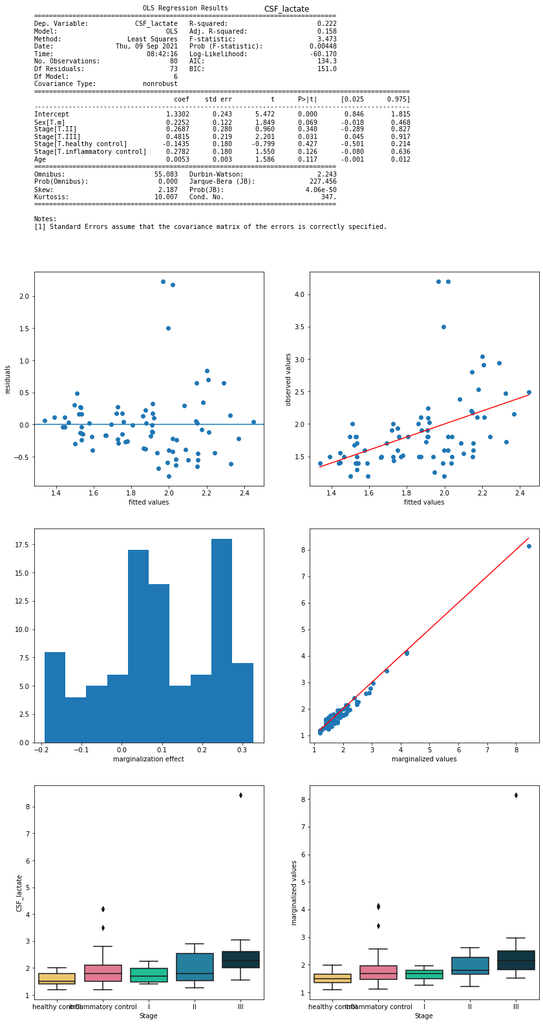

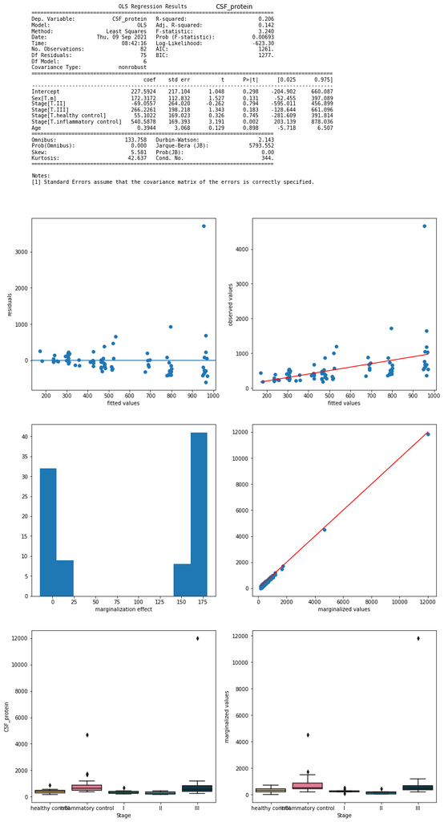

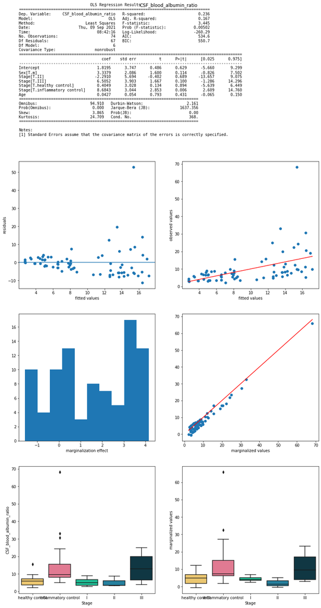

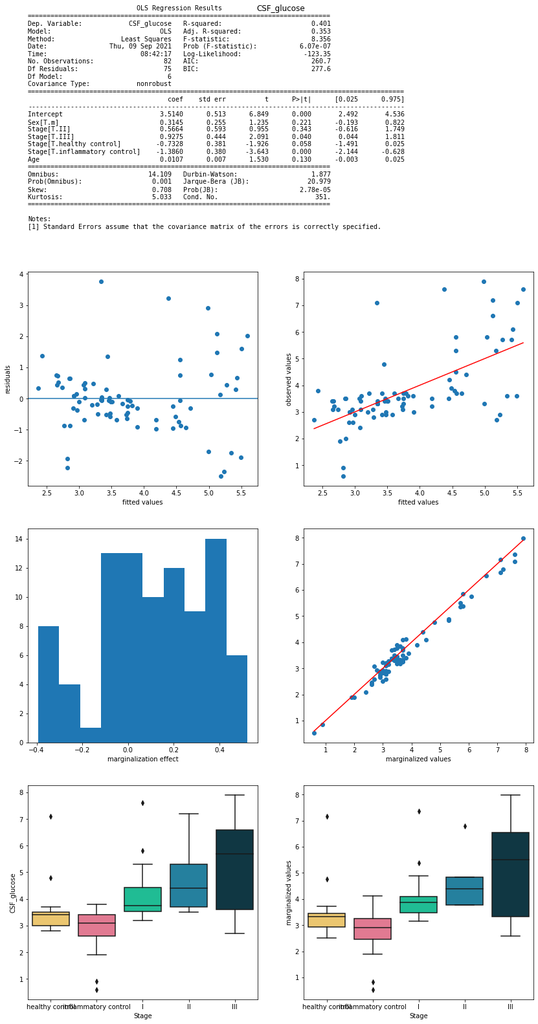

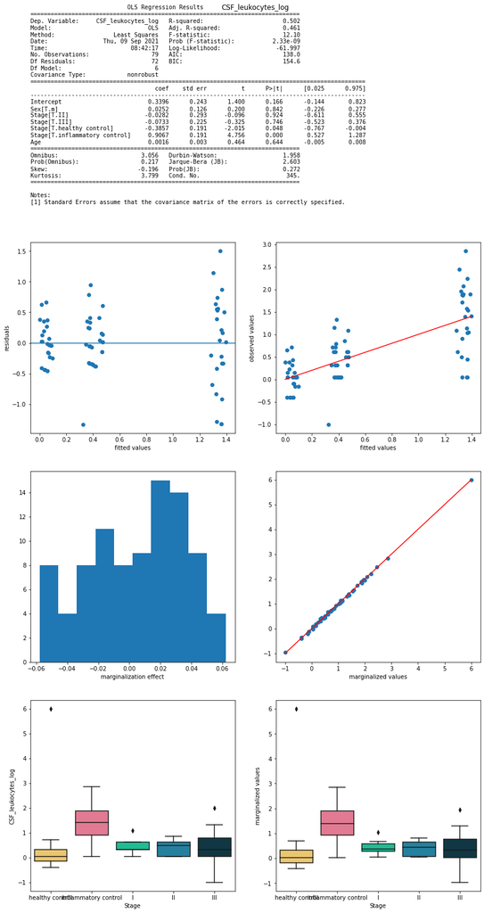

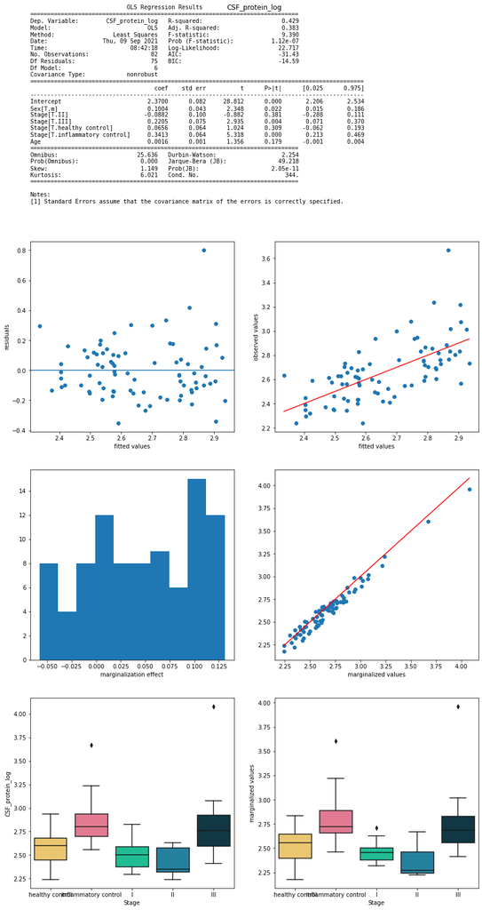

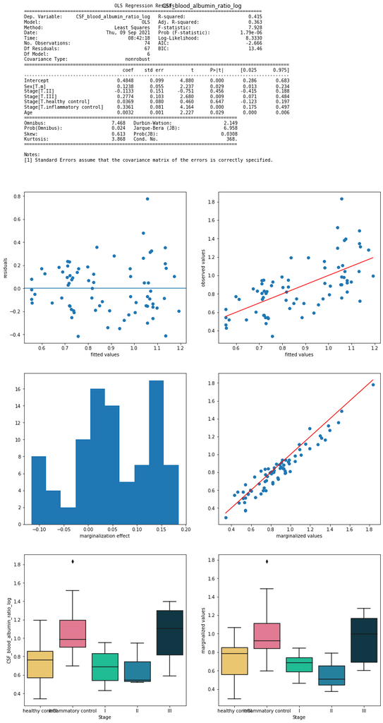

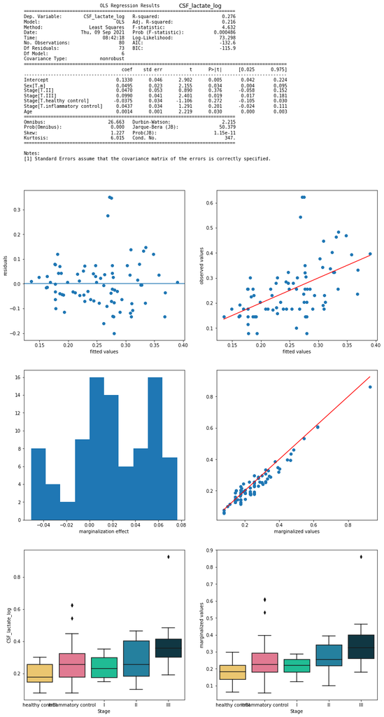

```python
marginalizedVals = {}

measures = [ "CSF_leukocytes","CSF_lactate","CSF_protein","CSF_blood_albumin_ratio","CSF_glucose",
           "CSF_leukocytes_log" , "CSF_protein_log","CSF_blood_albumin_ratio_log", "CSF_lactate_log"]

for molec in measures:
    results = smf.ols(molec+' ~ Age + Sex + Stage', data=df_merged_no_outliers).fit()

    ## using the model parameters to marginalize
    diffReference = sexDiff*results.params['Sex[T.m]'] + ageDiff*results.params['Age']

    marginalizedValues = df_merged[molec] - diffReference

    marginalizedVals[molec] = marginalizedValues

    # Creating a report of the model and marginalization as a pdf
    fig = plt.figure( figsize=(14,28) )

    gs = fig.add_gridspec(4,2)
    ax1 = fig.add_subplot(gs[0, :]) # ols report
    ax2 = fig.add_subplot(gs[1, 0]) # fitted vs residuals
    ax3 = fig.add_subplot(gs[1, 1]) # fitted vs. observed
    ax4 = fig.add_subplot(gs[2, 0]) # marginalization effect
    ax5 = fig.add_subplot(gs[2, 1]) # histogram observed, marginalization
    ax6 = fig.add_subplot(gs[3, 0]) # boxplot observed
    ax7 = fig.add_subplot(gs[3, 1]) # boxplot marginalized



    ## reporting
    ax1.text( 0,0, str( results.summary() ) , font='monospace' )
    ax1.set_title( molec )
    ax1.axis('off')


    ax2.plot( results.fittedvalues, results.resid ,'o')
    ax2.axhline(0)
    ax2.set_xlabel('fitted values')
    ax2.set_ylabel('residuals')

    ax3.plot( results.fittedvalues, results.resid+results.fittedvalues ,'o')
    m = min(results.fittedvalues)
    M = max(results.fittedvalues)
    ax3.plot( [m,M] , [m,M] , color='red')
    ax3.set_xlabel('fitted values')
    ax3.set_ylabel('observed values')


    ax4.hist(diffReference)
    ax4.set_xlabel("marginalization effect")

    #ax5.hist( marginalizedValues , alpha = 0.5 , label="observed")
    #ax5.hist( df_merged[molec] , color='red', alpha = 0.5, label='marginalized')
    #ax5.set_xlabel(molec)
    #ax5.legend()
    m = min(df_merged[molec])
    M = max(df_merged[molec])
    ax5.scatter(df_merged[molec],marginalizedValues)
    ax5.plot( [m,M] , [m,M] , color='red')
    ax5.set_xlabel( "observed values" )
    ax5.set_xlabel( "marginalized values" )


    sns.boxplot( x="Stage" , y = molec , data=df_merged , ax = ax6  , order = order5 , palette = palette5)

    sns.boxplot( x="Stage" , y = marginalizedValues , data=df_merged , ax = ax7  , order = order5 , palette = palette5)
    ax7.set_ylabel("marginalized values")

    fig.savefig("images/marginalization/neuroCOVID/Clinical_measure_"+molec+"_marginalization_report.pdf")
    #plt.close()
```

```python
df_marginal = pd.DataFrame( marginalizedVals )
df_marginal['stageGroup'] = df_merged['Stage']

df_marginal.head()
```

|  | CSF_leukocytes | CSF_lactate | CSF_protein | CSF_blood_albumin_ratio | CSF_glucose | CSF_leukocytes_log | CSF_protein_log | CSF_blood_albumin_ratio_log | CSF_lactate_log | stageGroup |
| --- | --- | --- | --- | --- | --- | --- | --- | --- | --- | --- |
| 4927 | 4.053489 | 1.604783 | 298.868607 | 4.151634 | 3.213796 | 0.674915 | 2.495353 | 0.581931 | 0.203728 | healthy control |
| 5050 | 3.045414 | 1.501864 | 229.714074 | 2.281974 | 3.240693 | -0.113987 | 2.509827 | 0.624995 | 0.188091 | healthy control |
| 5052 | 2.263599 | 1.764159 | 257.901540 | 4.001046 | 7.171836 | -0.366285 | 2.575588 | 0.754255 | 0.255721 | healthy control |
| 5062 | 2.974720 | 1.459432 | 113.546566 | 1.862626 | 3.462191 | 0.071628 | 2.389645 | 0.556167 | 0.175293 | healthy control |
| 5092 | 2.163461 | 1.458038 | 431.358301 | 7.671707 | 2.918418 | 0.397638 | 2.647853 | 0.892458 | 0.161436 | healthy control |

```python
df_marginal.to_csv("marginalized_data/data_clinical_marginalized_neuroCOVID.csv")
```

toc

## 3.3 Summary of marginalization results

The raw data was marginalized to account for discrepancies in the distribution of age and sex between group and reduce the effect of these variables using linear models, similar to what was done on the molecular data, with the following addenda.

- **CSF_glucose** : no additionnal note
- **CSF_lactate** :
  - patient NC040 was skewing the fit so it was excluded from the model (the data point remains, we only prevented it to skew the marginalization)
  - the data was log10-transformed to avoid heteroskedascticity
- **CSF_blood_albumin_ratio**:
  - the data was log10-transformed to avoid heteroskedascticity
- **CSF_protein**:
  - patient NC040 was skewing the fit so it was excluded from the model
  - the data was log10-transformed to avoid heteroskedascticity
- **CSF_leukocytes**:
  - patients NC040 and 5977 were skewing the fit so they were excluded from the model
  - log10-transformation: actually a log10(0.1 + raw value ) (presence of a 0.0 value in raw data)
  - even after log10-transformation the linear model was deemed inappropriate for this measurement.
  - we recommend **not using the marginalized data here**, and being very careful about conclusions. Nevertheless keeping the log10 transform looks like a good idea (at least for data representations)

### visual representation of the data kept after marginalization (ie. all marginalized except for leukocytes)

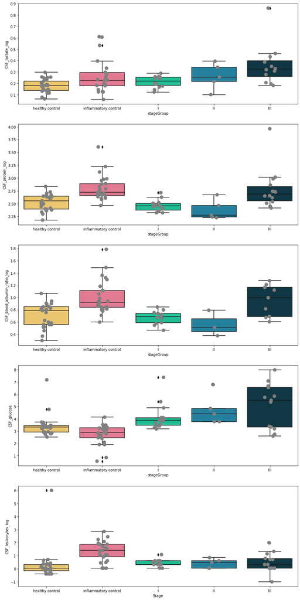

```python
# red/yellow / turquoise / blues
palette5 = {'III' :'#073B4C',
    'II' : '#118AB2',
       'I' : '#06D6A0',
    'healthy control' : '#FFCE5C',
    'inflammatory control' : '#F26989' }
Gorder = [ 'healthy control' ,'inflammatory control',  "I" , 'II' , "III" ]


fig,axes = plt.subplots(5,1,figsize=(14,6*5))
for i,col in enumerate([ "CSF_lactate_log","CSF_protein_log","CSF_blood_albumin_ratio_log","CSF_glucose"]):


    sns.boxplot( data = df_marginal , x = 'stageGroup' , y =col , palette=palette5,order=Gorder , ax = axes[i])
    sns.stripplot( data = df_marginal , x = 'stageGroup' , y = col , size=10,
                  color="grey",order=Gorder, ax=axes[i])

i = 4
col = "CSF_leukocytes_log"
sns.boxplot( data = df_merged , x = 'Stage' , y =col , palette=palette5,order=Gorder , ax = axes[i])
sns.stripplot( data = df_merged , x = 'Stage' , y = col , size=10,
                  color="grey",order=Gorder, ax=axes[i])
```

toc

## 4. marginalization of CSF/plasma glucose ratio

The CSF/plasma glucose ratio must be computed first, hence the special treatment.

### 4.1 reading de data and computing the ratio

the data is split among 2 data frames ; 1 for COVID patients, one for controls

```python
df1 = pd.read_csv('Severity_score_glucose_ratio.csv',
                 index_col=0 , header=1, skiprows=[2], na_values=['na'])
df1.head()
```

| Study ID | Usb Pat Number | USZ Pat Number | Age | Sex | Pre-existing illness | died in hospital | NeuroCOVID Stage | Follow-up | Long-COVID | Severity Score | Main neurological symptom | Glucose quotient (CSF/plasma) |
| --- | --- | --- | --- | --- | --- | --- | --- | --- | --- | --- | --- | --- |
| NC001 | 3595467.0 | NaN | 52 | male | NaN | 0 | II | memory problems, difficulties in daily activities | 1 | 4.0 | NaN | NaN |
| NC002 | 3142334.0 | NaN | 34 | female | NaN | 0 | II | concentration problems, memory problems, fatig... | 1 | 4.0 | NaN | 0.6 |
| NC003 | 3783056.0 | NaN | 48 | male | NaN | 0 | III | NaN | lost to follow up | 9.0 | NaN | 0.6 |
| NC004 | 3757171.0 | NaN | 59 | female | CLL | 0 | II | concentration problems, memory problems, fatig... | 1 | 4.0 | NaN | 0.5 |
| NC005 | 2145457.0 | NaN | 68 | male | arterial hypertension, diabetes mellitus, MGUS | 0 | II | concentration problems, memory problems | 1 | 4.0 | reduced vigilance, dizziness, headache | 0.4 |

```python
df1.columns
```

```
Index(['Usb Pat Number', 'USZ Pat Number', 'Age', 'Sex',
       'Pre-existing illness', 'died in hospital', 'NeuroCOVID Stage',
       'Follow-up', 'Long-COVID', 'Severity Score',
       'Main neurological symptom', 'Glucose quotient (CSF/plasma)'],
      dtype='object')
```

```python
df1['NeuroCOVID Stage'].value_counts()
```

```
I      18
III    15
II      7
Name: NeuroCOVID Stage, dtype: int64
```

```python
## let's actually merge this into the clinical info csv
df1bis = pd.read_table("../data/clinical_info.csv",
              index_col=0 , header=1, skiprows=[2], na_values=['na'])

df1bis.columns

df1bis.rename(columns={'Unnamed: 19':"Stage"} , inplace=True)
df1bis[ 'Glucose quotient (CSF/plasma)' ] = df1.loc[ df1bis.index , 'Glucose quotient (CSF/plasma)' ]
df1=df1bis
df1.head()
```

| Study ID | Usb Pat Number | Age | Sex | ICU / Stroke U | CSF Cell count (leukocytes) | CSF lactate | CSF protein | CSF blood albumin ratio | CSF glucose | Unnamed: 10 | ... | died in hospital | Stage | Date of admission/diagnosis | Date of LP | Date of blood withdrawal | Date of MRI/CT | imaging modality | Unnamed: 25 | Unnamed: 26 | Glucose quotient (CSF/plasma) |
| --- | --- | --- | --- | --- | --- | --- | --- | --- | --- | --- | --- | --- | --- | --- | --- | --- | --- | --- | --- | --- | --- |
| NC001 | 3595467.0 | 52 | male | 0 | NaN | NaN | NaN | NaN | NaN | NaN | ... | 0.0 | II | NaN | NaN | NaN | NaN | NaN | NaN | NaN | NaN |
| NC002 | 3142334.0 | 34 | female | 0 | 4.0 | 1.52 | 429.0 | NaN | 3.5 | NaN | ... | 0.0 | II | 8/16/2020 | 8/18/2020 | 8/18/2020 | 8/17/2020 | MRI | t1_mprage | NaN | 0.6 |
| NC003 | 3783056.0 | 48 | male | 1 | 14.0 | 2.94 | 881.0 | 19.9 | 5.7 | NaN | ... | 0.0 | III | 10/10/2020 | 10/13/2020 | 10/13/2020 | 10/23/2020 | MRI | t1_mprage | NaN | 0.6 |
| NC004 | 3757171.0 | 59 | female | 0 | 1.0 | 1.80 | 174.0 | NaN | 4.4 | NaN | ... | 0.0 | II | 10/19/2020 | 10/23/2020 | 10/23/2020 | 10/23/2020 | MRI | t1_mprage | NaN | 0.5 |
| NC005 | 2145457.0 | 68 | male | 0 | 7.0 | 2.53 | 378.0 | 8.8 | 7.2 | NaN | ... | 0.0 | II | 10/29/2020 | 11/2/2020 | 11/2/2020 | 10/29/2020 | MRI | t1_mprage | NaN | 0.4 |

5 rows × 27 columns

```python
df2 = pd.read_table("../data/Neurocovid_Hutter_Datasheet_08_06_2021_JO.csv", sep=',',
              index_col=1 , header=0, skiprows=[0,1,2,4], na_values=['na',''])

df2.Consens = df2.Consens.str.strip('"')

df2.head()
```

| Code | Unnamed: 0 | DOB | Age | gender | Consens | Date of LP | CSF erythrocytes | CSF colour | CSF lactate | Plasma lactate | ... | CSF total protein | CSF albumin | Albumin ratio CSF/serum | reference | Reiber IgG | Reiber IgA | Reiber IgM | IgG Index | Isoelectric focusing CSf specific bands | n bands |
| --- | --- | --- | --- | --- | --- | --- | --- | --- | --- | --- | --- | --- | --- | --- | --- | --- | --- | --- | --- | --- | --- |
| 4927 | 1 | 5/19/1970 | 38.7 | f | healthy control | 1/14/2009 | 0 | clear | 1.5 | 1.4 | ... | 291 | 153 | 3.3 | 6.6 | 0.0 | 0.0 | 0.0 | 0.50 | negative | 0 |
| 5050 | 1 | 1/12/1956 | 53.5 | m | healthy control | 7/7/2009 | 0 | clear | 1.7 | 1.2 | ... | 400 | 233 | 5.4 | 7.6 | 0.0 | 0.0 | 0.0 | 0.51 | negative | 0 |
| 5052 | 1 | 12/18/1986 | 22.6 | m | healthy control | 7/9/2009 | 0 | clear | 1.8 | 1.4 | ... | 416 | 271 | 5.8 | 5.5 | 0.0 | 0.0 | 0.0 | 0.48 | negative | 0 |
| 5062 | 1 | 2/11/1986 | 23.5 | m | healthy control | 7/28/2009 | 0 | clear | 1.5 | 1.3 | ... | 272 | 173 | 3.7 | 5.6 | 0.0 | 0.0 | 0.0 | 0.57 | negative | 0 |
| 5092 | 1 | 2/7/1962 | 47.6 | f | healthy control | 9/21/2009 | 0 | clear | 1.4 | 1.5 | ... | 427 | 266 | 7.2 | 7.2 | 0.0 | 0.0 | 0.0 | 0.54 | negative | 0 |

5 rows × 26 columns

```python
df2['Glucose quotient (CSF/plasma)'] = df2['CSF glucose']/ df2['Plasma glucose']
```

```python
controlColumns = ["Age","gender","Consens",
                  "CSF leukocytes",
                  "CSF total protein",
                  "Albumin ratio CSF/serum ",
                  "CSF lactate",
                  "CSF glucose",'Glucose quotient (CSF/plasma)']
covidColumns = ["Age","Sex","Stage",
                "CSF Cell count (leukocytes)",
                "CSF protein",
                "CSF blood albumin ratio",
                "CSF lactate",
                "CSF glucose",'Glucose quotient (CSF/plasma)']
```

```python
df2.loc[5977,controlColumns]
```

```
Age                                         59.3
gender                                         f
Consens                          healthy control
CSF leukocytes                         1000000.0
CSF total protein                            278
Albumin ratio CSF/serum                      6.4
CSF lactate                                  1.8
CSF glucose                                  3.7
Glucose quotient (CSF/plasma)           0.698113
Name: 5977, dtype: object
```

```python
sdf = df1.loc[ : , covidColumns ].rename( columns={"CSF Cell count (leukocytes)":"CSF_leukocytes",
                  "CSF protein":"CSF_protein",
                  "CSF blood albumin ratio":"CSF_blood_albumin_ratio",
                  "CSF lactate":"CSF_lactate",
                  "CSF glucose": "CSF_glucose"} )

sCdf = df2.loc[ : , controlColumns ].rename( columns={"gender":"Sex",
                                                  "Consens":"Stage",
                                                  "CSF total protein":"CSF_protein",
                                                  "Albumin ratio CSF/serum ":"CSF_blood_albumin_ratio",
                                                  "CSF lactate":"CSF_lactate",
                                                  "CSF glucose": "CSF_glucose",
                                                  "CSF leukocytes":"CSF_leukocytes"} )
```

```python
df_merged = pd.concat( [ sCdf , sdf] )
df_merged.head()
```

|  | Age | Sex | Stage | CSF_leukocytes | CSF_protein | CSF_blood_albumin_ratio | CSF_lactate | CSF_glucose | Glucose quotient (CSF/plasma) |
| --- | --- | --- | --- | --- | --- | --- | --- | --- | --- |
| 4927 | 38.7 | f | healthy control | 4.3 | 291.0 | 3.3 | 1.5 | 3.0 | 0.681818 |
| 5050 | 53.5 | m | healthy control | 0.7 | 400.0 | 5.4 | 1.7 | 3.5 | 0.538462 |
| 5052 | 22.6 | m | healthy control | 0.3 | 416.0 | 5.8 | 1.8 | 7.1 | 0.816092 |
| 5062 | 23.5 | m | healthy control | 1.0 | 272.0 | 3.7 | 1.5 | 3.4 | 0.739130 |
| 5092 | 47.6 | f | healthy control | 2.3 | 427.0 | 7.2 | 1.4 | 2.8 | 0.848485 |

```python
df_merged.loc[ df_merged['Glucose quotient (CSF/plasma)'].isna() , 'Stage' ].value_counts()
```

```
I                        9
inflammatory controll    7
healthy control          4
II                       3
III                      1
Name: Stage, dtype: int64
```

```python
df_merged.Sex = df_merged.Sex.str.replace("male","m")
df_merged.Sex = df_merged.Sex.str.replace("female","f")
df_merged.Sex = df_merged.Sex.str.replace("F","f")
df_merged.Sex = df_merged.Sex.str.replace("M","m")
df_merged.Sex = df_merged.Sex.str.replace("fem","f")
df_merged.Sex.value_counts()
```

```
m    49
f    41
Name: Sex, dtype: int64
```

```python
df_merged.Stage = df_merged.Stage.str.replace( "inflammatory controll","CNS inflammatory" )
df_merged.Stage.value_counts()
```

```
healthy control     25
CNS inflammatory    25
I                   18
III                 15
II                   7
Name: Stage, dtype: int64
```

```python
 df_merged.to_csv('supDocs/data_clinical_measurements.csv')
```

toc

### 4.2. testing marginalization

```python
df_merged.rename(columns={'Glucose quotient (CSF/plasma)':'CSF_plasma_glucose_ratio'}, inplace=True)
```

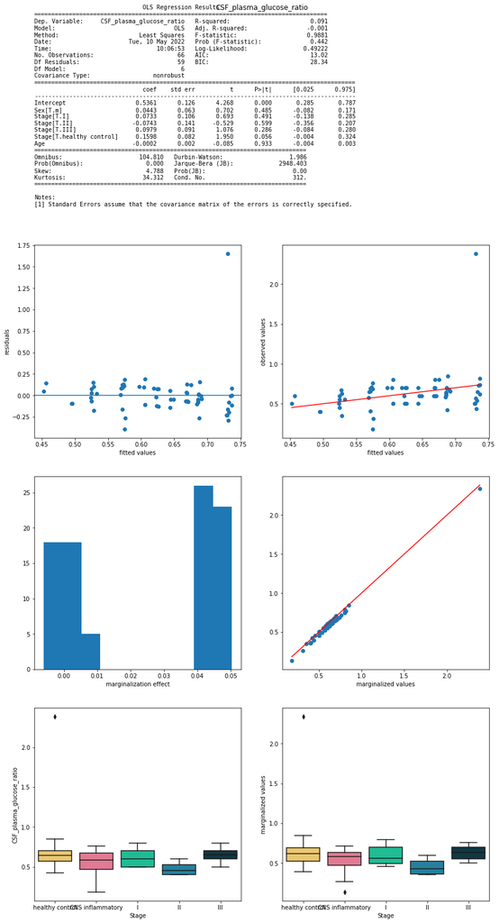

```python
import statsmodels.api as sm
import statsmodels.formula.api as smf

order5 = ['healthy control','CNS inflammatory','I','II','III']


## thankfully, the global median value is plausible for all categories (ie. close the the group medians and observed points)
medianAge = df_merged.Age.median()

ageDiff = df_merged.Age - medianAge
sexDiff = df_merged.Sex == 'm'


marginalizedVals = {}


molec='CSF_plasma_glucose_ratio'

results = smf.ols(molec+' ~ Age + Sex + Stage', data=df_merged).fit()

## using the model parameters to marginalize
diffReference = sexDiff*results.params['Sex[T.m]'] + ageDiff*results.params['Age']

marginalizedValues = df_merged[molec] - diffReference

marginalizedVals[molec] = marginalizedValues

# Creating a report of the model and marginalization as a pdf
fig = plt.figure( figsize=(14,28) )

gs = fig.add_gridspec(4,2)
ax1 = fig.add_subplot(gs[0, :]) # ols report
ax2 = fig.add_subplot(gs[1, 0]) # fitted vs residuals
ax3 = fig.add_subplot(gs[1, 1]) # fitted vs. observed
ax4 = fig.add_subplot(gs[2, 0]) # marginalization effect
ax5 = fig.add_subplot(gs[2, 1]) # histogram observed, marginalization
ax6 = fig.add_subplot(gs[3, 0]) # boxplot observed
ax7 = fig.add_subplot(gs[3, 1]) # boxplot marginalized



## reporting
ax1.text( 0,0, str( results.summary() ) , font='monospace' )
ax1.set_title( molec )
ax1.axis('off')


ax2.plot( results.fittedvalues, results.resid ,'o')
ax2.axhline(0)
ax2.set_xlabel('fitted values')
ax2.set_ylabel('residuals')

ax3.plot( results.fittedvalues, results.resid+results.fittedvalues ,'o')
m = min(results.fittedvalues)
M = max(results.fittedvalues)
ax3.plot( [m,M] , [m,M] , color='red')
ax3.set_xlabel('fitted values')
ax3.set_ylabel('observed values')


ax4.hist(diffReference)
ax4.set_xlabel("marginalization effect")

#ax5.hist( marginalizedValues , alpha = 0.5 , label="observed")
#ax5.hist( df_merged[molec] , color='red', alpha = 0.5, label='marginalized')
#ax5.set_xlabel(molec)
#ax5.legend()
m = min(df_merged[molec])
M = max(df_merged[molec])
ax5.scatter(df_merged[molec],marginalizedValues)
ax5.plot( [m,M] , [m,M] , color='red')
ax5.set_xlabel( "observed values" )
ax5.set_xlabel( "marginalized values" )


sns.boxplot( x="Stage" , y = molec , data=df_merged , ax = ax6  , order = order5 , palette = palette5)

sns.boxplot( x="Stage" , y = marginalizedValues , data=df_merged , ax = ax7  , order = order5 , palette = palette5)
ax7.set_ylabel("marginalized values")

fig.savefig("images/Clinical_measure_"+molec+"_marginalization_report.pdf")
```

So It would loook like the model explains very little in the data... so the marginalization is near useless here.

Let's try without the potential outlier ?

```python
m = df_merged['CSF_plasma_glucose_ratio'].idxmax()
print(m)
df2.loc[m,:]
```

```
5904
```

```
Unnamed: 0                                               1
DOB                                               8/4/1952
Age                                                   60.2
gender                                                   m
Consens                                    healthy control
Date of LP                                      10/19/2012
CSF erythrocytes                                         0
CSF colour                                           clear
CSF lactate                                            2.0
Plasma lactate                                         1.1
CSF glucose                                            3.1
Plasma glucose                                         1.3
glucose ratio CSF/plasma                               0.7
CSF leukocytes                                         0.6
mononuclear                                            1.0
polynuclear                                            0.0
CSF total protein                                      862
CSF albumin                                            584
Albumin ratio CSF/serum                               15.6
reference                                                8
Reiber IgG                                             0.0
Reiber IgA                                             0.0
Reiber IgM                                             0.0
IgG Index                                             0.48
Isoelectric focusing CSf specific bands           negative
n bands                                                  0
CSF/Plasma_glucose_ratio                          2.384615
Glucose quotient (CSF/plasma)                     2.384615
Name: 5904, dtype: object
```

```python
df_merged_no_outliers = df_merged.copy()
df_merged_no_outliers.loc[5904,"CSF_plasma_glucose_ratio"] = np.nan
#df_merged_no_outliers['CSF_plasma_glucose_ratio'].idxmax()
```

[output not shown]

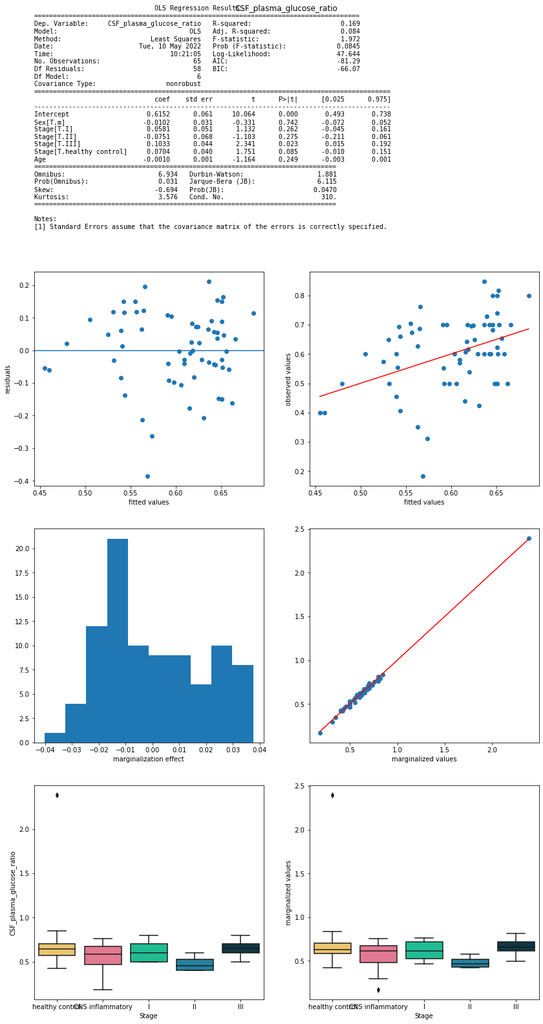

```python
import statsmodels.api as sm
import statsmodels.formula.api as smf

order5 = ['healthy control','CNS inflammatory','I','II','III']


## thankfully, the global median value is plausible for all categories (ie. close the the group medians and observed points)
medianAge = df_merged.Age.median()

ageDiff = df_merged.Age - medianAge
sexDiff = df_merged.Sex == 'm'


marginalizedVals = {}


molec='CSF_plasma_glucose_ratio'

results = smf.ols(molec+' ~ Age + Sex + Stage', data=df_merged_no_outliers).fit()

## using the model parameters to marginalize
diffReference = sexDiff*results.params['Sex[T.m]'] + ageDiff*results.params['Age']

marginalizedValues = df_merged[molec] - diffReference

marginalizedVals[molec] = marginalizedValues

# Creating a report of the model and marginalization as a pdf
fig = plt.figure( figsize=(14,28) )

gs = fig.add_gridspec(4,2)
ax1 = fig.add_subplot(gs[0, :]) # ols report
ax2 = fig.add_subplot(gs[1, 0]) # fitted vs residuals
ax3 = fig.add_subplot(gs[1, 1]) # fitted vs. observed
ax4 = fig.add_subplot(gs[2, 0]) # marginalization effect
ax5 = fig.add_subplot(gs[2, 1]) # histogram observed, marginalization
ax6 = fig.add_subplot(gs[3, 0]) # boxplot observed
ax7 = fig.add_subplot(gs[3, 1]) # boxplot marginalized



## reporting
ax1.text( 0,0, str( results.summary() ) , font='monospace' )
ax1.set_title( molec )
ax1.axis('off')


ax2.plot( results.fittedvalues, results.resid ,'o')
ax2.axhline(0)
ax2.set_xlabel('fitted values')
ax2.set_ylabel('residuals')

ax3.plot( results.fittedvalues, results.resid+results.fittedvalues ,'o')
m = min(results.fittedvalues)
M = max(results.fittedvalues)
ax3.plot( [m,M] , [m,M] , color='red')
ax3.set_xlabel('fitted values')
ax3.set_ylabel('observed values')


ax4.hist(diffReference)
ax4.set_xlabel("marginalization effect")

#ax5.hist( marginalizedValues , alpha = 0.5 , label="observed")
#ax5.hist( df_merged[molec] , color='red', alpha = 0.5, label='marginalized')
#ax5.set_xlabel(molec)
#ax5.legend()
m = min(df_merged[molec])
M = max(df_merged[molec])
ax5.scatter(df_merged[molec],marginalizedValues)
ax5.plot( [m,M] , [m,M] , color='red')
ax5.set_xlabel( "observed values" )
ax5.set_xlabel( "marginalized values" )


sns.boxplot( x="Stage" , y = molec , data=df_merged , ax = ax6  , order = order5 , palette = palette5)

sns.boxplot( x="Stage" , y = marginalizedValues , data=df_merged , ax = ax7  , order = order5 , palette = palette5)
ax7.set_ylabel("marginalized values")

fig.savefig("images/Clinical_measure_"+molec+"_marginalization_report.pdf")
```

# marginalization conclusion :

- marginalization of glucose ratio required the exclusion of outlier 5904 from the model (the data is kept)
- marginalization effect is likely to be minimal

```python
## trying log10 of ratio -> worse results
```

toc

### 4.3. output of marginalized data

let's import the other marginalized clinical values and integrate the marginalized ratio as a new column

```python
##
df_marginal = pd.read_csv("../marginalized_data/data_clinical_marginalized_neuroCOVID.csv", index_col=0)
df_marginal.head()
```

|  | CSF_leukocytes | CSF_lactate | CSF_protein | CSF_blood_albumin_ratio | CSF_glucose | CSF_leukocytes_log | CSF_protein_log | CSF_blood_albumin_ratio_log | CSF_lactate_log | stageGroup |
| --- | --- | --- | --- | --- | --- | --- | --- | --- | --- | --- |
| 4927 | 4.053489 | 1.604783 | 298.868607 | 4.151634 | 3.213796 | 0.674915 | 2.495353 | 0.581931 | 0.203728 | healthy control |
| 5050 | 3.045414 | 1.501864 | 229.714074 | 2.281974 | 3.240693 | -0.113987 | 2.509827 | 0.624995 | 0.188091 | healthy control |
| 5052 | 2.263599 | 1.764159 | 257.901540 | 4.001046 | 7.171836 | -0.366285 | 2.575588 | 0.754255 | 0.255721 | healthy control |
| 5062 | 2.974720 | 1.459432 | 113.546566 | 1.862626 | 3.462191 | 0.071628 | 2.389645 | 0.556167 | 0.175293 | healthy control |
| 5092 | 2.163461 | 1.458038 | 431.358301 | 7.671707 | 2.918418 | 0.397638 | 2.647853 | 0.892458 | 0.161436 | healthy control |

```python
marginalizedVals[molec].index = marginalizedVals[molec].index.astype(str)
```

```python
df_marginal.insert( df_marginal.shape[1]-1 , molec , marginalizedVals[molec][df_marginal.index])
df_marginal.head()
```

|  | CSF_leukocytes | CSF_lactate | CSF_protein | CSF_blood_albumin_ratio | CSF_glucose | CSF_leukocytes_log | CSF_protein_log | CSF_blood_albumin_ratio_log | CSF_lactate_log | CSF_plasma_glucose_ratio | stageGroup |
| --- | --- | --- | --- | --- | --- | --- | --- | --- | --- | --- | --- |
| 4927 | 4.053489 | 1.604783 | 298.868607 | 4.151634 | 3.213796 | 0.674915 | 2.495353 | 0.581931 | 0.203728 | 0.661376 | healthy control |
| 5050 | 3.045414 | 1.501864 | 229.714074 | 2.281974 | 3.240693 | -0.113987 | 2.509827 | 0.624995 | 0.188091 | 0.543405 | healthy control |
| 5052 | 2.263599 | 1.764159 | 257.901540 | 4.001046 | 7.171836 | -0.366285 | 2.575588 | 0.754255 | 0.255721 | 0.789374 | healthy control |
| 5062 | 2.974720 | 1.459432 | 113.546566 | 1.862626 | 3.462191 | 0.071628 | 2.389645 | 0.556167 | 0.175293 | 0.713334 | healthy control |
| 5092 | 2.163461 | 1.458038 | 431.358301 | 7.671707 | 2.918418 | 0.397638 | 2.647853 | 0.892458 | 0.161436 | 0.837162 | healthy control |

```python
df_marginal.to_csv("supDocs/data_clinical_measurements_marginalized.csv")
```